# Predicting Income with Bayesian Networks: A Case Study Using the Adult Income Dataset - Data Science Capstone

Author

Michael Zeihen, Maxime Martin, Sarah Burns, Seth Henry

Published

July 23, 2024

**NEW>>** Dataset & Summaries  
Slides

```r
# loading packages
library(rmarkdown)
library(tidyverse)
library(knitr)
library(ggthemes)
library(ggrepel)
library(dslabs)
library(datasets)
library(ggplot2)
library(cluster)
library(bnlearn)
library(e1071)
library(Rgraphviz)
library(tidyr)
library(dplyr)
```

# I) Introduction

### I-1. What is a “Bayesian Network”?

A Bayesian network, a belief network, or a probabilistic graphical model represents a set of variables and their conditional dependencies via a Directed Acyclic Graph (DAG). (Pearl 1986) EEach node in the graph represents a random variable, and the edges between the nodes represent probabilistic dependencies among these variables. Bayes’ theorem is a fundamental concept used in this network. Bayes’ theorem describes the probability of an event based on prior knowledge of conditions that might be related to the event. The formula for Bayes’ theorem is
$$P(A \mid B) = \frac{P(B \mid A) \cdot P(A)}{P(B)}$$

This equation describes how to update the probability of a hypothesis $(A)$ given new evidence $(B)$. Here, $P(A \mid B)$ is the posterior probability (the probability of $(A)$ given $(B)$), $P(B \mid A)$ is the likelihood (the probability of $(B)$ given $(A)$, $P(A)$ is the prior probability (the initial probability of $(A)$, and $P(B)$ is the marginal probability (the total probability of $(B)$. The theorem’s formulation is crucial for understanding how evidence impacts our belief in a hypothesis by combining prior knowledge with new evidence to provide an updated probability (Gelman 2022)

### I-2. What is the Bayesian Theorem?

A simple Bayesian network can be visualized as a directed acyclic graph (DAG) with nodes representing random variables and directed edges representing conditional dependencies between these variables. (Koller and Friedman 2009)

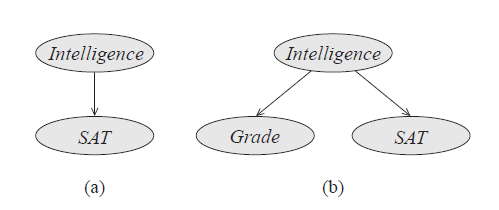

Figure 1: Simple Bayesian Network

Bayesian networks leverage Bayes’ theorem to update the probabilities of various hypotheses given new Evidence, allowing for probabilistic reasoning and decision-making under uncertainty. The process involves defining the network structure and conditional probabilities, calculating joint and marginal probabilities, and applying Bayes’ theorem to infer the posterior probabilities. (Koller and Friedman 2009)

An illustrative example of Bayes’ Theorem in action is the Bertrand box paradox. This paradox involves three boxes, one with two gold coins, one with two silver coins, and one with one gold and one silver coin. If a coin is randomly drawn from a box and it turns out to be gold, Bayes’ Theorem helps calculate the probability that the box with one gold and one silver coin was chosen. The theorem updates the probability based on the new evidence (the gold coin drawn) and the prior probability of each box being chosen. (FLUSSER 1984)

This paradox is often used to describe the Bayes’ Theorem. But instead of having two draws with outcomes being gold and silver, it’s the TV game show where a presenter make choose a player one of the three doors. Behind two of them are goats and behind one of them there is a car. Once the player made his choice, the presenter of the show will open one door where there is a goat and ask him if he wants to change door. By using the Bayes’ Theorem on this case, the result gives that the player has more chance to get the car by changing door. The whole principle of the Bayes’ equation is used in the Bayesian Networks when taking a look at the conditional probability tables.

### I-3. What are the advantages of using Bayesian Networks

Data analysis offers a variety of tools like rule-based systems, decision trees, and artificial neural networks, along with techniques such as density estimation, classification, regression, and clustering. (Heckerman 1995) What unique advantages do Bayesian networks and Bayesian methods bring to the table in this landscape?

In the paper “A Bayesian Method for the Induction of Probabilistic Networks from Data”(Cooper and Herskovits 1992), here are some of the advantages mentioned using Bayesian Networks:

Learning Causal Relationships:

Bayesian networks facilitate learning causal relationships, which are crucial for understanding complex systems and making predictions under interventions. For example, determining if increasing advertisement exposure causes higher product sales can be analyzed using Bayesian networks, even without direct experimental data.

Combining Domain Knowledge and Data:

Bayesian networks seamlessly integrate domain knowledge (prior knowledge) with data. This domain knowledge is particularly beneficial when data is limited or costly. Their causal semantics make it straightforward to incorporate prior knowledge about causal relationships, enhancing the accuracy and reliability of predictions.

Avoiding Overfitting:

Bayesian networks provide an efficient approach to prevent overfitting. They achieve this by “smoothing” models using all available data during training, eliminating the need to reserve data for testing purposes. Using all data ensures that models generalize well to new data and avoid capturing noise or spurious patterns from the training data.

### I-4. Applications of Bayesian Networks

We widely apply Bayesian networks across diverse fields due to their capabilities in modeling probabilistic relationships. A few examples are - In healthcare, they are used to examine how psychiatric, demographic, and socioeconomic variables interrelate (Bilek and Karaman 2018); in supply chain management, they can play a crucial role in assessing risks, evaluating resilience and analyzing ripple effects - aiding in making informed decisions among uncertainties(Hosseini and Ivanov 2020). In political studies, they can assist in predicting online participation patterns by analyzing user interactions and engagement metrics (Kopacheva 2021). Bayesian networks provide dynamic modeling, learning, and inference - enabling an understanding of evolving systems over time in various applications (Shiguihara, Lopes, and Mauricio 2021). All these example applications underscore the utility of Bayesian networks in addressing complex probabilistic challenges across different domains and further their practical usefulness.

### I-5. Components of Bayesian Networks

Bayesian networks are sophisticated models that represent probabilistic relationships among variables using a directed acyclic graph (DAG). The primary components of Bayesian networks include nodes, edges, and conditional probability distributions, each playing a crucial role in defining the network’s structure and behavior.

Nodes in a Bayesian network represent random variables. The classification of these variables falls into several categories based on their roles within the network. Parent nodes have outgoing edges to other nodes, signifying causal or influential relationships. On the other hand, child nodes are the recipients of these edges, representing variables influenced or caused by the parent nodes. Additionally, evidence nodes are those for which we have observed data; using these observations can update the beliefs about other variables in the network. Query nodes are the variables of interest for which we seek to compute posterior probabilities given the Evidence. This categorization helps organize and understand the information flow within the network (Pearl 1986).

Edges in a Bayesian network are directed and represent probabilistic dependencies between the nodes. An edge from node A to node B indicates that A is a parent of B, and the probability distribution of B is conditionally dependent on the state of A. This directional relationship is a critical aspect of Bayesian networks, as it encodes the causal assumptions and the flow of influence among the variables es (Pearl 1986).

The structure of a Bayesian network is a directed acyclic graph (DAG). A DAG is a directed graph containing no cycles. It is impossible to start at any node and follow a consistent direction along the edges to return to the starting node. This acyclic property is fundamental because it ensures no infinite loop in the probabilistic dependencies, allowing for coherent probabilistic inferences. The DAG structure facilitates the decomposition of the joint probability distribution of the variables into a product of conditional probability distributions, greatly simplifying the representation and computation of complex probabilistic models(Koller and Friedman 2009).

Probabilistic inferences in Bayesian networks involve computing the posterior probabilities of query nodes given the evidence nodes. This process uses the network’s structure and the conditional probability distributions to propagate information and update beliefs. One of the key concepts in performing these inferences is conditional independence, which allows for significant computational efficiency. Conditional independence means that a variable is independent of another variable given a set of other variables, reducing the number of direct dependencies that need to be considered (Koller and Friedman 2009).

Lastly, the conditional probability tree represents the conditional probability distributions associated with each node in the network. These trees show how each node’s probability depends on its parent nodes’ states, providing a visual and computational tool for working with the network’s probabilistic relationships (Pearl 1986).

Understanding these components, nodes, edges, the directed acyclic graph, probabilistic inferences, conditional independence, and the conditional probability tree provides a foundational framework for working with Bayesian networks, enabling the modeling of complex systems with interdependent variables in a structured and efficient manner.

### I-6. Limitations of Bayesian Networks

Although Bayesian networks are valuable in modeling and predicting probabilistic relationships, they have their limitations that can hinder effectiveness.

**Complexity**: One issue is their complexity, which increases with the number of variables introduced. Complexity makes Bayesian Networks computationally intensive to build and maintain for large, highly connected networks, making real-time inference and updates challenging. Data Requirements: Bayesian networks are largely data-driven; thus, the data requirements make sparse data sets potentially compromise reliability.

**Assumptions**: Bayesian networks mainly involve assumptions in defining relationships between variables and often use expert inputs, thus being open to subjectivity and biases (Kubsch et al. 2021). Bayesian models assume that variables are conditionally independent given their parents in the network. In this case, violations of these assumptions affect the correctness of the predictions made with these models.

**Structure:** The structure is another critical limitation. Developing a Bayesian network structure does not automatically adapt to new data or changes in the problem domain.

**Scalability**: Scalability is a significant limitation: Large networks require substantial computational effort for exact inference and typically rely on approximations, resulting in lower accuracy, noting this significant limitation (Jewell et al. 2009). Bayesian networks are also limited in that they cannot model complex relationships and nonlinearity between variables; it makes them less successful in modeling real-world complex interactions compared to other approaches, say, neural networks. These limitations stress that careful application and possible use of hybrid methodologies may be necessary when solving complex problems with Bayesian networks.

# II) Methods

dataset link: https://www.kaggle.com/datasets/uciml/adult-census-income

The main goal is to predict whether an individual’s income exceeds $50,000 per year based on various demographic and employment-related attributes.

### II-1. Steps to create a Bayesian netowrk

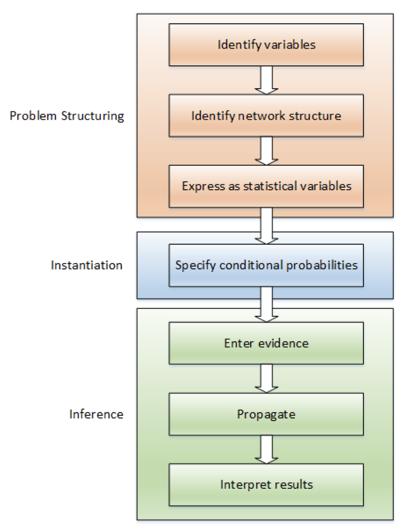

Figure 2: Steps necessary to build and use BNs for safety and reliability analysis (Sigurdsson, Walls, and Quigley 2001)

Here are the descriptions for each step, as described in “Bayesian belief nets for managing expert judgment and modeling reliability” (Sigurdsson, Walls, and Quigley 2001).

**1. Identify Variables**

The first step in constructing a Bayesian Network is to identify and include all relevant variables for the model. These variables represent the different aspects of the problem domain that need to be analyzed. Variables can be continuous or discrete and should be chosen based on their relevance to the problem and available data. With continuous variables, the work will be more complicated regarding discretization because we should base our analysis on expert knowledge. On the other hand, discrete variables are easier to handle but provide less information about the data.

**2. Identify Network Structure**

The BNLearn package in R provides various algorithms for learning the network structure from data, such as the Hill-Climbing algorithm, Tabu search, and constraint-based methods like the PC algorithm. Using the graphviz.plot() function from the Rgraphviz package, which also supports visualization.

**3. Specify Conditional Probabilities**

After establishing the network structure, the next step is specifying each variable’s conditional probability distributions. Each node in the network must define its conditional probability distribution given its parent nodes. Then, we can get the conditional probability tables (CPT), the results interface of our modelization.

These probabilities can be estimated from data or provided by domain experts. The BNLearn package can fit these probabilities to data using maximum likelihood estimation or Bayesian estimation methods. (Heckerman 1995)

**4. Enter Evidence**

Entering Evidence involves incorporating observed values for certain variables into the Bayesian Network, often called “instantiating” or “clamping” variables. This process updates the network to reflect the current state of knowledge, enabling the computation of posterior probabilities for other variables. The purposes of entering Evidence include conditioning the network to calculate posterior probabilities of unobserved variables, aiding in medical diagnosis by using symptoms or test results to identify the likelihood of diseases and supporting decision-making by updating beliefs based on the most probable outcomes. The process involves identifying which variables have observed values from real-world data, experimental results, or expert knowledge and then updating the network with these values to adjust the probabilities accordingly..

The cpquery function in BNLearn enables entering Evidence, conditioning on it, and querying the network to determine the posterior probabilities of the remaining variables.

**5. Propagate**

Propagation in a Bayesian Network refers to computing the posterior distributions of the unobserved variables given the observed Evidence. One can perform propagation using various exact and approximate inference algorithms.

Belief propagation in Bayesian networks, as described in (Pearl 1986), involves the iterative updating of probabilities through the network’s nodes to achieve a consistent set of beliefs. This process leverages the network’s structure, which encodes conditional dependencies among variables, allowing for the efficient computation of marginal and joint probabilities. The joint probability function plays a central role, as it is decomposed into a product of conditional probabilities corresponding to the network’s edges.

Through belief propagation, local computations are performed at each node, combining incoming messages (probability distributions) from neighboring nodes and sending updated messages back. This iterative exchange continues until convergence, enabling the network to incorporate new evidence and update beliefs consistently across the entire system. Pearl’s framework revolutionized probabilistic reasoning by making complex probabilistic inference computationally feasible.

The joint probability function is a fundamental concept in probability theory and statistics, representing the probability of simultaneous occurrences of a set of random variables. For a set of random variables $X_1, X_2, \ldots, X_n$, the joint probability function $P(X_1 = x_1, X_2 = x_2, \ldots, X_n = x_n)$ gives the likelihood that these variables take on specific values $(x_1, x_2, \ldots, x_n)$. In the context of Bayesian networks, the joint probability distribution of a set of variables can be factorized into a product of conditional probabilities based on the network’s structure, which is typically a directed acyclic graph (DAG). This factorization is expressed as:

$P(X_1, X_2, \ldots, X_n) = \prod_{i=1}^n P(X_i \mid \text{Parents}(X_i))$,

where $\text{Parents}(X_i)$ denotes the set of parent nodes for the node $(X_i)$ in the Bayesian network. This factorization leverages the conditional independence properties encoded in the network, significantly simplifying the computation of the joint distribution. (Friedman, Geiger, and Goldszmidt 1997)

The BNLearn package provides functions like “grain” for exact inference and “bn.fit” for approximate inference using sampling methods such as Markov Chain Monte Carlo (MCMC).

**6. Interpret Result**

The final step is to interpret the results obtained from the propagation step. Interpreting results involves analyzing the posterior distributions to make decisions and predictions or to gain insights into the relationships between variables. (Cowell et al. 2003)

# III) Analyse and visualisation

## III-1. Dataset and description

This data was sourced from the 1994 Census Bureau database by Ronny Kohavi and Barry Becker (Becker and Kohavi 1996)They extracted a set of relatively clean records using these criteria: ((AAGE>16) && (AGI>100) && (AFNLWGT>1) && (HRSWK>0)). (Becker and Kohavi 1996) The objective is to predict whether an individual earns more than $50K annually.

```r
dataset <- read.csv("data/adult.csv")
dataset[dataset == "?"] <- NA
# TCP process becomes to large for limits of R(12.5gb) need to prunce some nodes atm

dataset <- na.omit(dataset)
dataset <- subset(dataset, select = -fnlwgt)
dataset <- subset(dataset, select = -education.num)


#dataset$fnlwgt <- as.factor(dataset$fnlwgt)

#dataset$education.num <- as.factor(dataset$education.num)

head(dataset) %>%
  kable(caption = "Head of the Adult income Dataset")
```

Head of the Adult income Dataset

|  | age | workclass | education | marital.status | occupation | relationship | race | sex | capital.gain | capital.loss | hours.per.week | native.country | income |
| --- | --- | --- | --- | --- | --- | --- | --- | --- | --- | --- | --- | --- | --- |
| 2 | 82 | Private | HS-grad | Widowed | Exec-managerial | Not-in-family | White | Female | 0 | 4356 | 18 | United-States | <=50K |
| 4 | 54 | Private | 7th-8th | Divorced | Machine-op-inspct | Unmarried | White | Female | 0 | 3900 | 40 | United-States | <=50K |
| 5 | 41 | Private | Some-college | Separated | Prof-specialty | Own-child | White | Female | 0 | 3900 | 40 | United-States | <=50K |
| 6 | 34 | Private | HS-grad | Divorced | Other-service | Unmarried | White | Female | 0 | 3770 | 45 | United-States | <=50K |
| 7 | 38 | Private | 10th | Separated | Adm-clerical | Unmarried | White | Male | 0 | 3770 | 40 | United-States | <=50K |
| 8 | 74 | State-gov | Doctorate | Never-married | Prof-specialty | Other-relative | White | Female | 0 | 3683 | 20 | United-States | >50K |

### III-1.a Define Variables and Dependencies:

| Feature | Description |
| --- | --- |
| age | age |
| workclass | Work type |
| fnlwgt | Current Population Survey (CPS) Weights |
| education | Education level |
| education.num | Education level number |
| marital.status | Marital Status |
| occupation | occupation |
| relationship | family relationship |
| race |  |
| sex | Gender |
| capital.gain | Capital Gain |
| capital.loss | Capital Loss |
| hours.per.week | Working hours per week |
| native.country | Native nationality |
| income | income |

**Age:** Age is divided into three categories to account for the differences in education level and career progression. Younger individuals may still be in college and may not be as advanced in their career paths.

→ Categories: Young, Middle, Retired → Dependencies: Education

**Workclass:** Type of employment affects income. There are vast variations in salary and benefits, as well as different career opportunities among different fields of study/work. → Categories: Federal-gov, Local-gov, Private, Self-employed-inc, Self-employed-not-inc, State-gov, Without-pay, etc. → Dependencies: Hours per Week

**Education:** TThe level of education attained is a significant determinant because it typically measures eligibility for particular jobs, career promotion opportunities, and earnings. A higher education level means more income compared to lower education. → Categories: 10th - 12th grade, HS-grad, Some-college, Assoc-acdm, Assoc-voc, Bachelors, Masters, Prof-school, etc. → Dependencies: Occupation

**Marital Status:** Marital status indicates the status of household dynamics and economic dependencies, which affect the level of income. For instance, married individuals may benefit from dual incomes, whereas divorced or widowed individuals may be responsible for other fiscal commitments and constraints. → Categories: Unmarried, Divorced, Separated, Never-married, Widowed, etc. → Dependencies: Relationship

**Occupation:** The nature of the occupation directly determines income levels as a function of the varied pay scales and promotional opportunities among the different occupational categories. → Categories: Exec-managerial, Machine-op-inspct, Prof-speciality, Adm-clerical, Other-service, etc. → Dependencies: Workclass

**Relationship:** The family relationship status might affect income because of financial dependencies or household dynamics such as a family with kids or no kids. → Categories: Not-in-family, Unmarried, Own-child, Other-relative, etc. → Dependencies: Income

**Race: Ethnicity.** → Categories: Black, White, Asian-Pac-Islander, etc. → Dependencies: Occupation, Education

**Capital Gain:** Capital gain means additional sources of income and represents money invested financially, which influences total income. → Categories: Low, etc. → Dependencies: Income

**Capital Loss:** Loss from Investments. → Categories: Low, etc. → Dependencies: Income

**Hours per Week:** The hours put in work per week are directly associated with income, as it affects earnings coming through wages or salary. → Categories: Partime, FullTime, Overtime, etc. → Dependencies: Income

**Native Country:** Country of birth can affect income due to the effect of educational opportunities, conditions in the job market, and economic policy. → Category: United States, Mexico, Greece, etc. → Dependencies: Income

**Sex: Gender of Individual:** → Categories: Male, Female → Dependencies: Occupation, Education

### III-1.b Data pre-processing:

Column Exclusions: We excluded the columns ‘fnlwgt’ and ‘education.num’ from the dataset. ‘Education.num’ duplicates the information already captured by the ‘education’ column, which represents education levels comprehensively. We removed ‘Fnlwgt,’ which contained Current Population Survey (CPS) weights because Bayesian Networks focus on modeling causal relationships among variables. CPS weights are statistical adjustments applied after sampling to correct biases rather than causal factors.

Capital Gain and Loss Grouping: We categorized capital gain and loss into distinct groups: ‘Low’ (0 to 4,999), ‘Medium’ (5,000 to 9,999), ‘High’ (10,000 to 19,999), and ‘Rich’ (20,000 to 100,000).

Factor Conversion: To facilitate modeling, we converted the following columns into categorical factors: ‘race,’ ‘native.country’, ‘workclass,’ ‘education,’ ‘marital.status’, ‘occupation,’ ‘relationship,’ ‘sex,’ and ‘income.’

```r
# Data transformation

breaks <- c(18, 40, 65, 100)  # Adjust as needed
labels <- c("Young", "Middle", "Retired")
dataset$age <- cut(dataset$age, breaks = breaks, labels = labels, include.lowest = TRUE)

breaks <- c(0, 5000, 10000, 20000, 100000)  # Adjust as needed
labels <- c("Low", "Medium", "High", "Rich")
dataset$capital.gain  <- cut(dataset$capital.gain, breaks = breaks, labels = labels, include.lowest = TRUE)
dataset$capital.loss  <- cut(dataset$capital.loss, breaks = breaks, labels = labels, include.lowest = TRUE)

breaks <- c(0, 35, 40, 200)  # Adjust as needed
labels <- c("Partime", "FullTIme", "Overtime")
dataset$hours.per.week <- cut(dataset$hours.per.week, breaks = breaks, labels = labels, include.lowest = TRUE)

dataset$race <- as.factor(dataset$race)
dataset$native.country <- as.factor(dataset$native.country)
dataset$workclass <- as.factor(dataset$workclass)
dataset$education <- as.factor(dataset$education)
dataset$marital.status <- as.factor(dataset$marital.status)
dataset$occupation <- as.factor(dataset$occupation)
dataset$relationship <- as.factor(dataset$relationship)
dataset$sex <- as.factor(dataset$sex)
dataset$income <- as.factor(dataset$income)
```

```r
### this is bayes classifier code
# Split the data into training and test sets
#set.seed(123)  # For reproducibility
#sample_index <- sample(1:nrow(dataset), 0.7 * nrow(dataset))  # 70% training data
#train_data <- dataset[sample_index, ]
#test_data <- dataset[-sample_index, ]
### Train the Naive Bayes model
#nb_model <- naiveBayes(income ~ ., data = train_data)
#
## Predict on the test data
#predictions <- predict(nb_model, test_data)
#
## Evaluate the model
#confusion_matrix <- table(predictions, test_data$income)
#print(confusion_matrix)
#
## Calculate accuracy
#accuracy <- sum(diag(confusion_matrix)) / sum(confusion_matrix)
#print(paste("Accuracy:", accuracy))
```

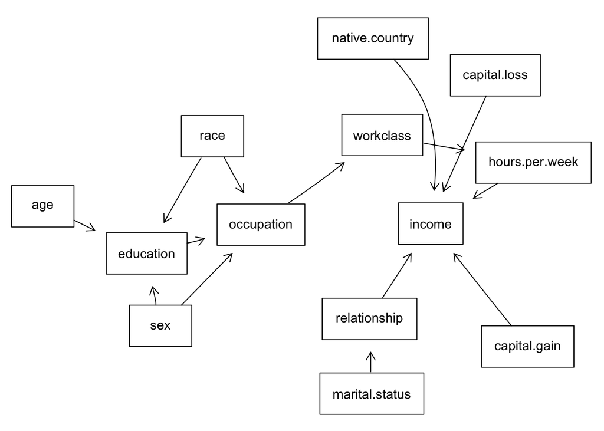

```r
features = c("age","workclass","capital.gain","capital.loss",
"hours.per.week", "education","marital.status","relationship",
"occupation","sex", "native.country","race",
"income")

dag = empty.graph(features)

#conditional
dag = set.arc(dag, from = "age", to = "education")
dag = set.arc(dag, from = "education", to = "occupation")
dag = set.arc(dag, from = "occupation", to = "workclass")
dag = set.arc(dag, from = "workclass", to = "hours.per.week")
dag = set.arc(dag, from = "marital.status", to = "relationship")

dag = set.arc(dag, from = "sex", to = "occupation")
dag = set.arc(dag, from = "sex", to = "education")

dag = set.arc(dag, from = "race", to = "occupation")
dag = set.arc(dag, from = "race", to = "education")
dag = set.arc(dag, from = "hours.per.week", to = "income")

dag = set.arc(dag, from = "native.country", to = "income")
dag = set.arc(dag, from = "relationship", to = "income")
dag = set.arc(dag, from = "capital.gain", to = "income")
dag = set.arc(dag, from = "capital.loss", to = "income")

graphviz.plot(dag, layout = "fdp")
```

Define Variables and Dependencies:

Assign Conditional Probability Tables (CPTs):

Inference:

Learning: structure and parameter

Decision Support:

Validation and Sensitivity Analysis: monte carlo

## III-2. Data shaping and Visualization

The distribution of income is significantly influenced by age. Individuals aged between 18 and 39 years typically earn $50,000 or less annually. This is likely because they are in the early stages of their careers and have not yet attained a high level of education or substantial work experience. Conversely, those aged between 40 and 64 years are more likely to earn over $50,000 annually, reflecting their greater experience and more advanced career stages. Most workers are employed in the private sector, which tends to employ younger individuals with varying education levels, although at least a bachelor’s degree is commonly observed. Notably, workers with a doctorate level of education often earn more than $50,000 per year. Gender also plays a role in income distribution. Higher-earning individuals are predominantly male, with jobs in categories such as “exec-managerial” and “prof-specialty,” which are typically male-dominated. In contrast, occupations often filled by women, such as “adm-clerical” and “other-service,” generally lead to lower incomes. Most occupations with incomes above $50,000 are in the “Exec-managerial” and “Prof-specialty” categories, followed by “Sales,” “Craft-repair,” and “Adm-clerical.” However, within each of these occupational categories, the majority of workers earn $50,000 or less annually.

**Age Distribution by Income** Individuals between the ages of 18 and 39, categorized as “young,” have a larger majority who are making $50,000 or less a year. Individuals between the ages of 40 and 64, categorized as “middle,” have a higher number of people making over $50,000. It is important to note that the “young” category has a much larger sample size. The amount of “middle-aged” individuals making over $50,000 is not much larger than the amount of “young” individuals. Retired individuals have a much smaller sample size, with the majority making under $50,000.

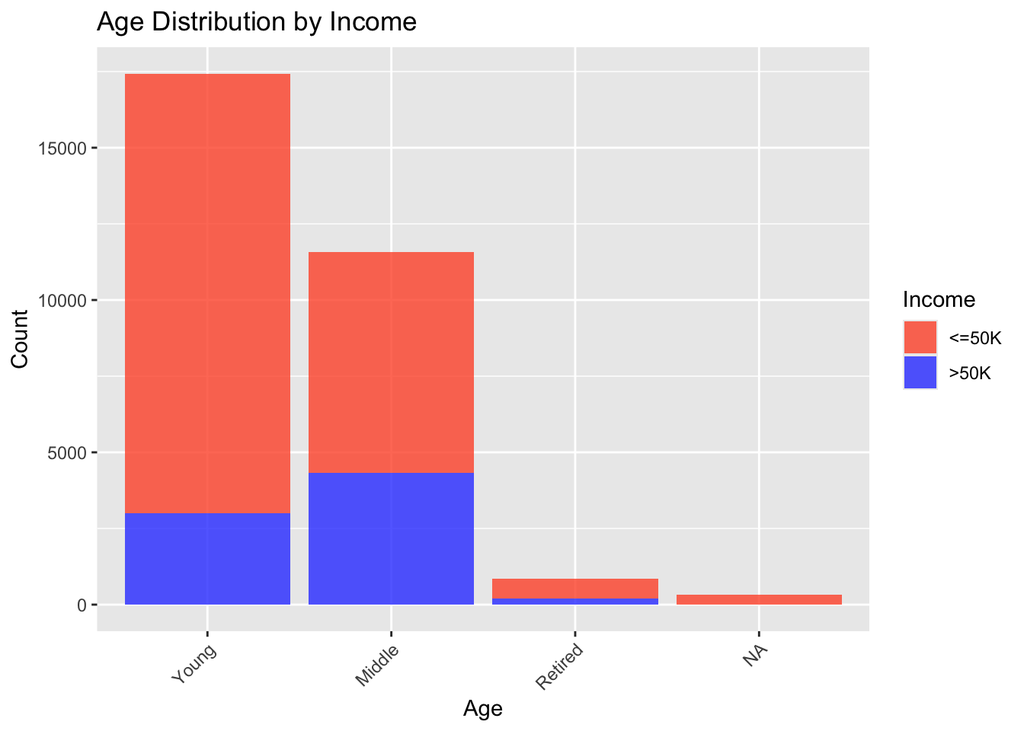

```r
ggplot(data = dataset, aes(x = age, fill = income)) +

# Add density plots for each income category
geom_bar(position = "stack", alpha = 0.8) +  # Adjust alpha for transparency

# Customize colors for each income category
scale_fill_manual(values = c("#FF5733", "#3349FF")) +  # Adjust colors as needed

# Label axes and add title
labs(x = "Age", y = "Count", title = "Age Distribution by Income") +

# Rotate x-axis labels for better readability
theme(axis.text.x = element_text(angle = 45, hjust = 1)) +

# Customize legend
guides(fill = guide_legend(title = "Income"))
```

**Workclass**

The majority of individuals in the census data work in the private sector and make $50,000 or less; this makes sense considering how a large percentage of individuals in the dataset are grouped in the “young” category. In addition, the trend in education is lower level education, such as being a high school graduate, having some college, or having a bachelor’s.

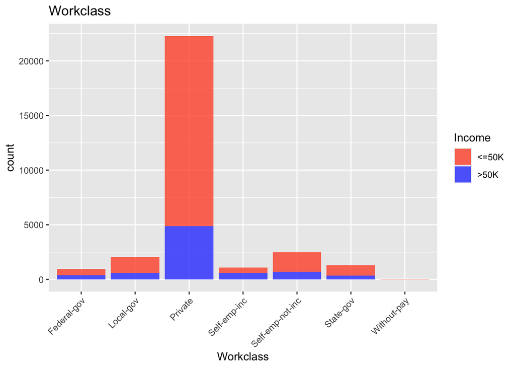

```r
ggplot(data = dataset, aes(x = workclass, fill = income)) +

# Add a histogram with stacked bars
geom_bar(position = "stack", alpha = 0.8) +  # Adjust alpha for transparency

# Customize colors for each income category
scale_fill_manual(values = c("#FF5733", "#3349FF")) +  # Adjust colors as needed

# Label axes and add title
labs(x = "Workclass", title = "Workclass") +

# Rotate x-axis labels for better readability
theme(axis.text.x = element_text(angle = 45, hjust = 1)) +

# Add legend for income categories
guides(fill = guide_legend(title = "Income"))
```

**Education**

Most people in the census data have either graduated high school, have had some college, or have a bachelor’s degree. A vast majority of people who have obtained a doctorate degree make over $50,000. About half of people who obtained their master’s make over $50,000. A little under half of the people who obtained their bachelors make over $50,000. Most people stopped their education at high school, or some college, and make under $50,000.

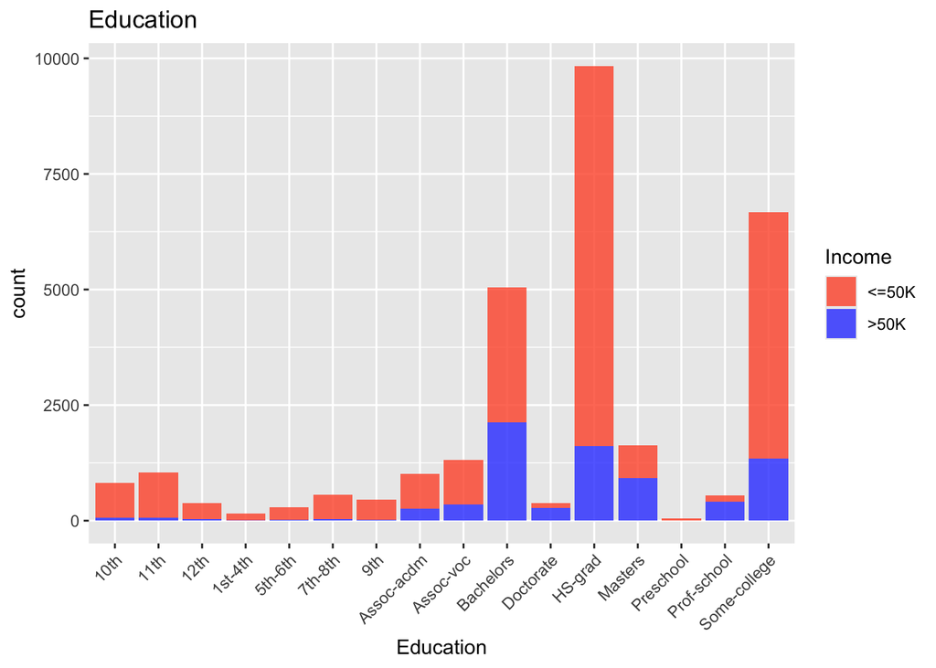

```r
ggplot(data = dataset, aes(x = education, fill = income)) +

# Add a histogram with stacked bars
geom_bar(position = "stack", alpha = 0.8) +  # Adjust alpha for transparency

# Customize colors for each income category
scale_fill_manual(values = c("#FF5733", "#3349FF")) +  # Adjust colors as needed

# Label axes and add title
labs(x = "Education", title = "Education") +

# Rotate x-axis labels for better readability
theme(axis.text.x = element_text(angle = 45, hjust = 1)) +

# Add legend for income categories
guides(fill = guide_legend(title = "Income"))
```

**Number of Males and Females Making Above and Below $50,000**

Almost half of the data consists of males making under $50,000. About a quarter of the data consists of males making over $50,000. The other quarter consists of females making under $50,000. There is a small percentage of the data with women making over $50,000.

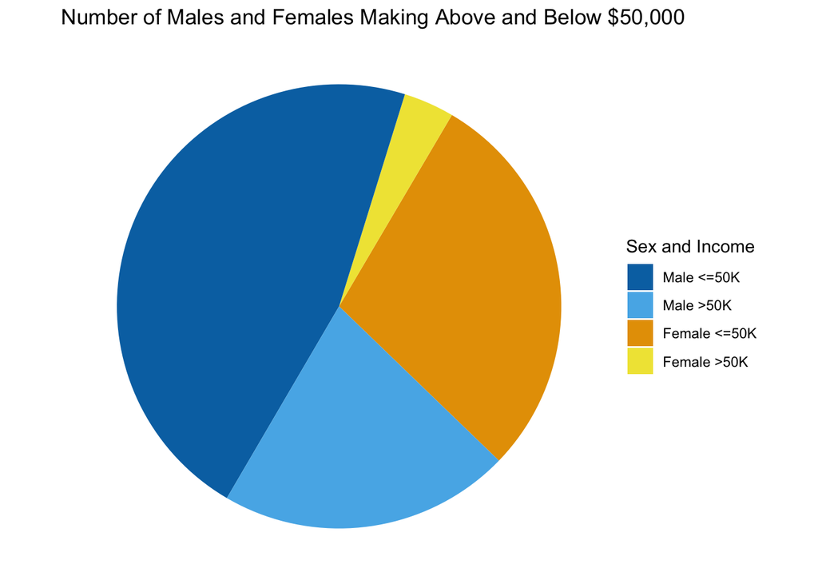

```r
sex_income_count <- dataset %>%
  group_by(sex, income) %>%
  summarise(count = n()) %>%
  ungroup()

# Combine sex and income into a single factor with ordered levels
sex_income_count <- sex_income_count %>%
  mutate(sex_income = factor(interaction(sex, income),
                             levels = c("Male.<=50K", "Male.>50K", "Female.<=50K", "Female.>50K"),
                             labels = c("Male <=50K", "Male >50K", "Female <=50K", "Female >50K")))


# Create custom color palette
my_colors <- c("#0072B2", "#56B4E9", "#E69F00", "#F0E442")

# Create the pie chart with custom colors and clockwise rotation
ggplot(sex_income_count, aes(x = "", y = count, fill = sex_income)) +
  geom_bar(stat = "identity", width = 1) +
  coord_polar("y", start = 38) +  # Rotate the pie chart clockwise by 20%
  scale_fill_manual(values = my_colors) +  # Set custom colors
  labs(title = "Number of Males and Females Making Above and Below $50,000",
       fill = "Sex and Income") +
  theme_void() +
  theme(legend.position = "right")
```

**Number of Males and Females in Each Occupation**